# Benchmarking Structural Variant Callers using NA12878 WGS reference

David Fuh, Summer Intern, Garvan Institute of Medical Research, Kinghorn Centre for Clinical Genomics, Sydney, NSW, Australia

2022-02-10

# Packages

```r
library(tidyverse)
library(paletteer)
library(patchwork)
library(GenomicRanges)
library(StructuralVariantAnnotation)
```

# Truth SV set of NA12878

```r
setwd("~/GitRepo/summerproject2021/NA12878_benchmark/VCF")

## NA12878 truth set: personlis + spiral, hg38
personalis_vcf <- readVcf("test_personalis_hg38.vcf", "hg38") ## > 2k DEL data
spiral_vcf <- readVcf("test_spiral_hg38.vcf", "hg38") ## Only 68 entries!

## truth set is biased towards DEL calls
## Check the sv type distribution among callers at 35X
## and see if correction is needed.

## Are there other sources (e.g. 1k genome project) that contains
## other validated SV data from NA12878
## so we can increase the diversity of SV types in our truth set?

## joining personalis data and spiral genetics data into one vcf
truth_vcf <- rbind(personalis_vcf, spiral_vcf)

## generate truth_svgr: note 2X count
truth_svgr <- breakpointRanges(truth_vcf)
```

# Importing VCF from GATK-SV & SvABA

```r
setwd("~/GitRepo/summerproject2021/NA12878_benchmark/VCF")
# 35X
delly_vcf <- readVcf("NA12878.delly.vcf", "hg38")
manta_vcf <- readVcf("NA12878.manta.vcf", "hg38")
melt_vcf <- readVcf("NA12878.melt.vcf", "hg38")
wham_vcf <- readVcf("NA12878.wham.vcf", "hg38")
svaba_vcf <- readVcf("NA12878.svaba.vcf", "hg38")

# 18X
ft_delly_vcf <- readVcf("NA12878_50pc_sampled.delly.vcf", "hg38")
ft_manta_vcf <- readVcf("NA12878_50pc_sampled.manta.vcf", "hg38")
ft_melt_vcf <- readVcf("NA12878_50pc_sampled.melt.vcf", "hg38")
ft_wham_vcf <- readVcf("NA12878_50pc_sampled.wham.vcf", "hg38")
ft_svaba_vcf <- readVcf("NA12878_50pc_sampled.svaba.vcf", "hg38")

# 6X
med_delly_vcf <- readVcf("NA12878_med.delly.vcf", "hg38")
med_manta_vcf <- readVcf("NA12878_med.manta.vcf", "hg38")
med_melt_vcf <- readVcf("NA12878_med.melt.vcf", "hg38")
med_wham_vcf <- readVcf("NA12878_med.wham.vcf", "hg38")
med_svaba_vcf <- readVcf("NA12878_med.svaba.vcf", "hg38")
```

# VCF to svgr by genomicRanges

```r
# 35X
delly_svgr <- breakpointRanges(delly_vcf)
manta_svgr <- breakpointRanges(manta_vcf)
melt_svgr <- breakpointRanges(melt_vcf)
wham_svgr <- breakpointRanges(wham_vcf)
svaba_svgr <- breakpointRanges(svaba_vcf)

# 18X
ft_delly_svgr <- breakpointRanges(ft_delly_vcf)
ft_manta_svgr <- breakpointRanges(ft_manta_vcf)
ft_melt_svgr <- breakpointRanges(ft_melt_vcf)
ft_wham_svgr <- breakpointRanges(ft_wham_vcf)
ft_svaba_svgr <- breakpointRanges(ft_svaba_vcf)

# 6X
med_delly_svgr <- breakpointRanges(med_delly_vcf)
med_manta_svgr <- breakpointRanges(med_manta_vcf)
med_melt_svgr <- breakpointRanges(med_melt_vcf)
med_wham_svgr <- breakpointRanges(med_wham_vcf)
med_svaba_svgr <- breakpointRanges(med_svaba_vcf)
```

## Filter

```r
# 35X
delly_svgr=subset(delly_svgr, delly_svgr@elementMetadata[, 5] == "PASS") ## 7816/39070
manta_svgr=subset(manta_svgr, manta_svgr@elementMetadata[, 5] == "PASS") ## 12080/14174
melt_svgr=subset(melt_svgr, melt_svgr@elementMetadata[, 5] == "PASS") ## 2006/3782
wham_svgr=subset(wham_svgr, wham_svgr@elementMetadata[, 5] == "PASS") ## 12788/12788
svaba_svgr=subset(svaba_svgr, svaba_svgr@elementMetadata[, 5] == "PASS") ## 5804/5804

# 18X
ft_delly_svgr=subset(ft_delly_svgr, ft_delly_svgr@elementMetadata[, 5] == "PASS")
ft_manta_svgr=subset(ft_manta_svgr, ft_manta_svgr@elementMetadata[, 5] == "PASS")
ft_melt_svgr=subset(ft_melt_svgr, ft_melt_svgr@elementMetadata[, 5] == "PASS")
ft_wham_svgr=subset(ft_wham_svgr, ft_wham_svgr@elementMetadata[, 5] == "PASS")
ft_svaba_svgr=subset(ft_svaba_svgr, ft_svaba_svgr@elementMetadata[, 5] == "PASS")

# 6X
med_delly_svgr=subset(med_delly_svgr, med_delly_svgr@elementMetadata[, 5] == "PASS") ## 1544/?
med_manta_svgr=subset(med_manta_svgr, med_manta_svgr@elementMetadata[, 5] == "PASS") ## 474/?
med_melt_svgr=subset(med_melt_svgr, med_melt_svgr@elementMetadata[, 5] == "PASS") ## 904/?
med_wham_svgr=subset(med_wham_svgr, med_wham_svgr@elementMetadata[, 5] == "PASS") ## 2118/?
med_svaba_svgr=subset(med_svaba_svgr, med_svaba_svgr@elementMetadata[, 5] == "PASS") ## 1070/?
```

## Assign caller info

```r
# 35X
delly_svgr$Caller <- "Delly"
manta_svgr$Caller <- "Manta"
melt_svgr$Caller <- "Melt"
wham_svgr$Caller <- "Wham"
svaba_svgr$Caller <- "SvABA"

# 18X
ft_delly_svgr$Caller <- "Delly"
ft_manta_svgr$Caller <- "Manta"
ft_melt_svgr$Caller <- "Melt"
ft_wham_svgr$Caller <- "Wham"
ft_svaba_svgr$Caller <- "SvABA"

# 6X
med_delly_svgr$Caller <- "Delly"
med_manta_svgr$Caller <- "Manta"
med_melt_svgr$Caller <- "Melt"
med_wham_svgr$Caller <- "Wham"
med_svaba_svgr$Caller <- "SvABA"
```

## Assigning coverage (Cov) info

Estimates*:

- “Full/Large” file: 35X
- “50pc”: 18X
- “Medium”: 6X
- “Small”: 1X (Omitted)

*These numbers need to be confirmed by samtools etc. We only eyeballed the overall depth using our header_maprate_depth workflow on Terra.

```r
# 35X
delly_svgr$Cov <- "35x"
manta_svgr$Cov <- "35x"
melt_svgr$Cov <- "35x"
wham_svgr$Cov <- "35x"
svaba_svgr$Cov <- "35x"

# 18X
ft_delly_svgr$Cov <- "18x"
ft_manta_svgr$Cov <- "18x"
ft_melt_svgr$Cov <- "18x"
ft_wham_svgr$Cov <- "18x"
ft_svaba_svgr$Cov <- "18x"

# 6X
med_delly_svgr$Cov <- "6x"
med_manta_svgr$Cov <- "6x"
med_melt_svgr$Cov <- "6x"
med_wham_svgr$Cov <- "6x"
med_svaba_svgr$Cov <- "6x"
```

# Precision / Recall

## Generating truth matches

A variant call (made by either caller) is matched against the validated truth set (NA12878) with countBreakpointOverlaps.

(BioC::StructuralVariantAnnotation/Papenfuss Lab, WEHI)

The criteria for a true positive are:

```
Breakpoint overlap > 0 (i.e. At least one breakend "overlapping" with a true call)
```

The overlapping criteria:

```
1. (Padding) "maxgap=200" allows each breakend a window of 200 bp between a call and a validated true variant

2. (Size difference) "sizemargin=0.25" ensures two variants do not differ their size by 0.25 of their mean (? this needs to be confirmed in vignette)

3. (Distance cap) "restrictMarginToSizeMultiple=0.5" restricts the distance between two variants to be at most 0.5 times the mean size of both variant. This prevents matching two (smaller) calls that are too far away from each other but were tolerated due to the 200 bp padding design.

4. (Deduplication) "countOnlyBest=TRUE" ensures that duplicate calls that differ slightly in breakend positions are counted as one. We are unsure if this argument was necessary for our workflow but included it as a safety measure.*
```

*Some variant callers, such as Hydra, are known to duplicate calls. We are not sure if in the GATK callers or SvABA algorithm similar situation can arise. This should be able to be confirmed in literature.

Note that in the following steps, we applied the same measure/constraints for every caller at every depth level, regardless of the “style” each caller performs when calling a variant. We are interested in whether we can fine-tune these measures for each caller so that our results are less biased.

```r
# 35X
delly_svgr$truth_matches <- countBreakpointOverlaps(delly_svgr, truth_svgr,
                                              maxgap=200, sizemargin=0.25,
                                              restrictMarginToSizeMultiple=0.5, countOnlyBest=TRUE)
manta_svgr$truth_matches <- countBreakpointOverlaps(manta_svgr, truth_svgr,
                                              maxgap=200, sizemargin=0.25,
                                              restrictMarginToSizeMultiple=0.5, countOnlyBest=TRUE)
melt_svgr$truth_matches <- countBreakpointOverlaps(melt_svgr, truth_svgr,
                                              maxgap=200, sizemargin=0.25,
                                              restrictMarginToSizeMultiple=0.5, countOnlyBest=TRUE)
wham_svgr$truth_matches <- countBreakpointOverlaps(wham_svgr, truth_svgr,
                                              maxgap=200, sizemargin=0.25,
                                              restrictMarginToSizeMultiple=0.5, countOnlyBest=TRUE)
svaba_svgr$truth_matches <- countBreakpointOverlaps(svaba_svgr, truth_svgr,
                                              maxgap=200, sizemargin=0.25,
                                              restrictMarginToSizeMultiple=0.5, countOnlyBest=TRUE)
# 35X svgr concatenation
large_svgr <- c(delly_svgr, manta_svgr, melt_svgr, wham_svgr, svaba_svgr)



# 18X
ft_delly_svgr$truth_matches <- countBreakpointOverlaps(ft_delly_svgr, truth_svgr, maxgap=200, sizemargin=0.25,
                                                          restrictMarginToSizeMultiple=0.5, countOnlyBest=TRUE)
ft_manta_svgr$truth_matches <- countBreakpointOverlaps(ft_manta_svgr, truth_svgr, maxgap=200, sizemargin=0.25,
                                                          restrictMarginToSizeMultiple=0.5, countOnlyBest=TRUE)
ft_melt_svgr$truth_matches <- countBreakpointOverlaps(ft_melt_svgr, truth_svgr, maxgap=200, sizemargin=0.25,
                                                         restrictMarginToSizeMultiple=0.5, countOnlyBest=TRUE)
ft_wham_svgr$truth_matches <- countBreakpointOverlaps(ft_wham_svgr, truth_svgr, maxgap=200, sizemargin=0.25,
                                                         restrictMarginToSizeMultiple=0.5, countOnlyBest=TRUE)
ft_svaba_svgr$truth_matches <- countBreakpointOverlaps(ft_svaba_svgr, truth_svgr, maxgap=200, sizemargin=0.25,
                                                          restrictMarginToSizeMultiple=0.5, countOnlyBest=TRUE)

# 18X svgr concatenation
ft_svgr <- c(ft_delly_svgr, ft_manta_svgr, ft_melt_svgr, ft_wham_svgr, ft_svaba_svgr)



# 6X
med_delly_svgr$truth_matches <- countBreakpointOverlaps(med_delly_svgr, truth_svgr,
                                              maxgap=200, sizemargin=0.25,
                                              restrictMarginToSizeMultiple=0.5, countOnlyBest=TRUE)
med_manta_svgr$truth_matches <- countBreakpointOverlaps(med_manta_svgr, truth_svgr,
                                              maxgap=200, sizemargin=0.25,
                                              restrictMarginToSizeMultiple=0.5, countOnlyBest=TRUE)
med_melt_svgr$truth_matches <- countBreakpointOverlaps(med_melt_svgr, truth_svgr,
                                              maxgap=200, sizemargin=0.25,
                                              restrictMarginToSizeMultiple=0.5, countOnlyBest=TRUE)
med_wham_svgr$truth_matches <- countBreakpointOverlaps(med_wham_svgr, truth_svgr,
                                              maxgap=200, sizemargin=0.25,
                                              restrictMarginToSizeMultiple=0.5, countOnlyBest=TRUE)
med_svaba_svgr$truth_matches <- countBreakpointOverlaps(med_svaba_svgr, truth_svgr,
                                              maxgap=200, sizemargin=0.25,
                                              restrictMarginToSizeMultiple=0.5, countOnlyBest=TRUE)
# 6X svgr concatenation
med_svgr <- c(med_delly_svgr, med_manta_svgr, med_melt_svgr, med_wham_svgr, med_svaba_svgr)
```

## Generating precision-recall (PR) data

```r
PR=data.frame()

# extract the key variables
# we need for each caller at each coverage level:

# Precision = n(TP)/n(Calls made by a caller)
# Recall = n(TP)/n(true variants)

# where TP = true positive is a variant call that has at least one breakpoint overlap
# with those in the validated true set.

## 35X
PR_large = as.data.frame(large_svgr) %>%

         dplyr::select(Caller, truth_matches) %>%

         dplyr::group_by(Caller) %>%

    dplyr::summarise(

      calls=dplyr::n(), ## total calls made by each caller at 35X

      tp=sum(truth_matches > 0)) %>% ## true positive counts for each caller at 35X

    dplyr::mutate(

      fp=calls-tp, ## false positive counts (FP) are calls made by a caller that are not true

      Precision=tp/calls, ## precision := true positive calls/total calls made by each caller

      Recall=tp/length(truth_svgr) ## recall := true positive calls/total counts of  validated variants
      )

PR_large$Cov <- "35X" ## assigning coverage info to data frame


## Similarly for 18X
PR_fiftypc = as.data.frame(ft_svgr) %>%

  dplyr::select(Caller, truth_matches) %>%
  dplyr::group_by(Caller) %>%

  dplyr::summarise(
    calls=dplyr::n(),
    tp=sum(truth_matches > 0)) %>%

  dplyr::mutate(
    fp=calls-tp,
    Precision=tp/calls,
    Recall=tp/length(truth_svgr)
  )

PR_fiftypc$Cov <- "18X"



## 6X
PR_medium = as.data.frame(med_svgr) %>%

  dplyr::select(Caller, truth_matches) %>%
  dplyr::group_by(Caller) %>%

  dplyr::summarise(
      calls=dplyr::n(),
      tp=sum(truth_matches > 0)) %>%

  dplyr::mutate(
      fp=calls-tp,
      Precision=tp/calls,
      Recall=tp/length(truth_svgr)
      )

PR_medium$Cov <- "6X"

# join these statistics into one data frame
PR=plyr::join(PR_large, PR_medium, type = "full") %>% plyr::join(., PR_fiftypc, type = "full")

# reorder panel header level for PR plot below
PR$Cov <- factor(PR$Cov, levels = c("35X", "18X", "6X"))
```

## Plotting precision-recall statistics

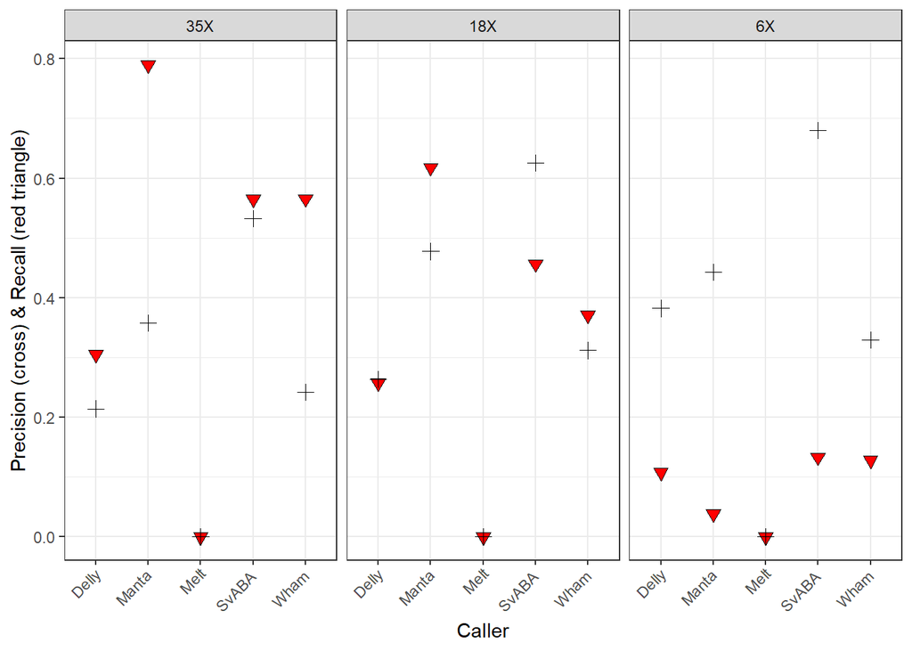

```r
# plot
ggplot(PR) +
  geom_point(aes(x=Caller, y=Recall), shape=25, fill="red", size=2.5) +
  geom_point(aes(x=Caller, y=Precision), shape=3, size=2.7) +
  facet_wrap(~Cov, nrow=1) +
  theme_bw() + theme(axis.text.x = element_text(angle = 45, hjust=1.2 ,vjust=1.2)) +
  ylab("Precision (cross) & Recall (red triangle)")
```

Note that Melt has no true positive counts at each coverage level. Our hypothesis is that this has to do with the way Melt calls variants — Melt is designed to report small mobile element insertions (MEIs) that have an overall size of ~280 bp. Our truth set was biased towards deletions (Personalis data ~2k deletions / ~2k+68 calls validated) of sizes from 50 bp to well-over 20Mb. As a result, we need to expand and critique the true set before re-analysing the following benchmarking data.

However, due to the time constraint and the scope for this project, we will carry on with our analysis by omitting Melt from our benchmarking study.

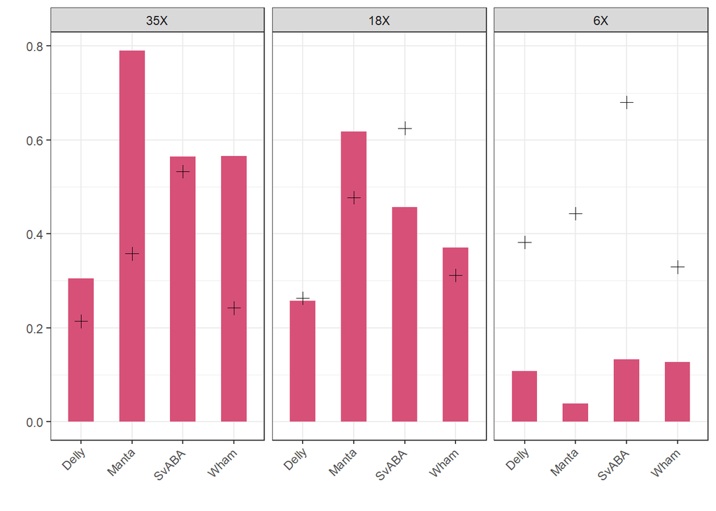

```r
PR %>% filter(Caller != "Melt") %>%
  ggplot() +
  geom_bar(aes(x=Caller, y=Recall), fill="#D75078", stat="identity", width=0.5) +
  geom_point(aes(x=Caller, y=Precision), shape=3, size=2.7) +
  facet_wrap(~Cov, nrow=1) +
  theme_bw() + theme(axis.text.x = element_text(angle = 45, hjust=1.2 ,vjust=1.2)) +
  xlab("") + ylab("")
```